# 基于知识图谱跑的生物力学研究进展分析

高瞻乐

# 1 前沿

跑是人体运动的基本动作。同时跑也是世界上最流行的体育运动之一，在中国一年有超过500万人次的跑步赛事<sup>[1]</sup>。跑的科学研究主要是从生理情况和动作进行研究，而跑的动作研究主要是应用生物力学的研究方法。尽管跑被认为是一项简单的运动，但却涉及到全身关节及环节共39次的运动整合<sup>[2]</sup>。跑的动作影响着跑的速度与人体能量的消耗，也是跑步损伤的直接因素。跑的生物力学研究能够了解跑的动作特征和人体力学机制，有助于提高跑的运动表现和减少损伤几率。国际上早在80年代就开始对跑的生物力学进行研究，近年随着世界体育健身的发展跑的生物力学研究也成为热潮。由于跑的生物力学涉及研究领域广泛，研究的主题比较扩散。因此通过文献计量法，借助CiteSpace可视化软件对其进行可视化能更科学的了解其研究进展。  
CiteSpace是由美国德雷塞尔大学（Drexel）信息科学与技术学院陈超美教授与大连理工大学WISE实验室联合开发的信息可视化软件，是用来分析和可视共引网络的Java应用程序<sup>[3]</sup>。CiteSpace在国际科学研究有具有广泛应用，涉及计算机科学、信息和图书馆学、工程及商业信息等<sup>[4]</sup>。国内的CiteSpace相关研究呈增长趋势，其在体育学<sup>[5–15]</sup>中也有较多的应用。 本文对Web of Science数据库中涉及跑的运动生物力学研究文献的主要内容、脉络及热点进行分析与回顾，研究的结果有助于学者更好的了解跑的生物力学国际现状和发展动向，为跑的相关研究提供一定的参考依据。

# 2 研究思路

通过CiteSpace对文献数据进行统计分析，了解国际跑的生物力学研究基本情况。使用文献数据带有的Web of Science™分类标引进行归类，分析跑的生物力学所涉及学科研究领域。利用关键词分析研究热点和研究前沿。进一步对文献数据共被引分析，提取重要作者与重要文献，继而结合引文聚类阐述研究的主要内容和历史演进。

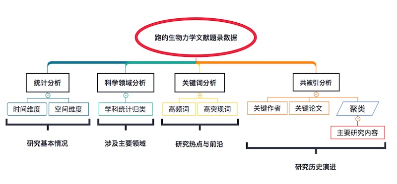

# 3 数据采集策略与研究方法

## 3.1 数据获取

研究数据来源于Web of Science<sup>TM</sup>（WOS）核心数据库SCI-E，数据下载日期为2018年2月4日。检索条件：主题为跑步（run*[^1]）、慢跑（jog）、冲刺（sprint）和马拉松（marathon）与主题为生物力学（biomchanics）的交集，文献类型为期刊（Article）。排除研究领域动物学（Zoology），植物科学（Plant Science）和声学（Acoustics）。时间跨度为1985-2017。 检索结果得到文献1619篇（表1）。

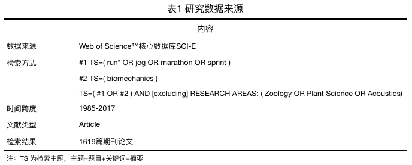

## 3.2 研究方法

使用Rstudio（1.1.414版本64位）对检索数据中的来源（论文发表时间、国家、机构、领域、作者）进行描述统计分析。  
使用CiteSpaceV（5.1.R8SE版本64位）可视化工具对检索得到的文献数据进行分析并绘制科学知识图谱。将检索得到的数据导入CiteSpaceV中。主题来源选择文献标题（Title）、摘要（Abstract）、作者关键词（Author Keywords）和补增关键词（Keywords Plus），数据时区分割（time slice）为1年<sup>[16]</sup>。

# 4 名词释义

1. Centranlity（中介中心性）：是测度节点在网络中重要性的指标，数值越大则在网络中的重要性越高。
2. Burst（突现值）：CiteSpace使用Kleinberg的突变检测算法可以用于检测一个学科内研究兴趣的突然增长<sup>[17]</sup>，数值越大突现性越高。
3. Sigma指数：是中介中心性和和突现值的综合体现，数值越大表明中介中心性和突现性越大。

# 5 结果分析

## 5.1 数据的时间维度分析

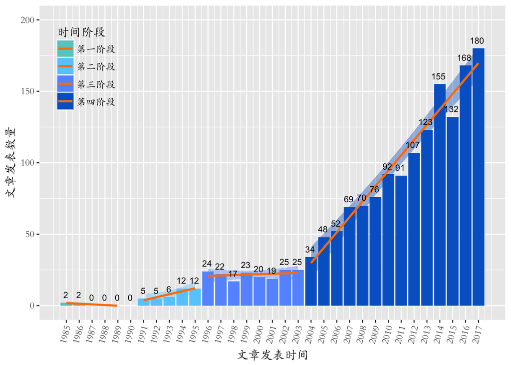

图 1985-2017年跑的生物力学论文发表情况

经统计分析表明跑步在生物力学研究领域中研究2004年以前相对较少，上升趋势不明显。2004年以后更多的学者加入此方面的研究，文献发表量趋势处于上升趋势。

## 5.2 数据的空间维度分析

### 5.2.1 国家分布状况

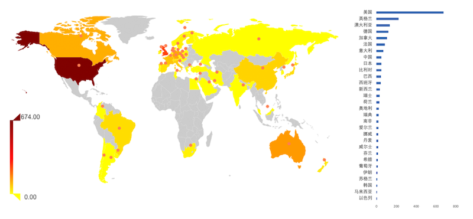

图2 1985-2017年跑的生物力学研究国家分布

### 5.2.2 机构研究状况

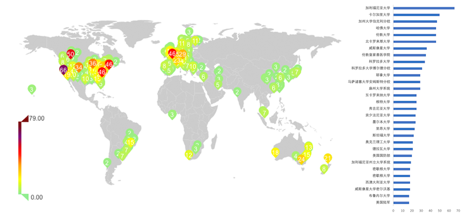

图3 1985-2017年跑的生物力学研究机构分布

## 5.3 跑的生物力学研究的学科领域结构分析

Web of Science将收录的论文根据其内容所涉及的研究领域进行225种分类标引，这些分类在文献计量学研究中广泛的应用于定义学科的研究领域<sup>[18]</sup>。对数据的研究领域分布情况进行分析，可获知研究主题的分布情况<sup>[19]</sup>。跑的生物力学中涉及许多学科领域，对这些学科领域进行分析可得知跑的生物力学中包所含的学科领域及学科领域的分布情况。

### 5.3.1 跑的生物力学学科领域统计

表2 跑步在生物力学研究的学科领域统计

| 排名 | 研究领域 | 数量 | 百分比 | 中文 |
| --- | --- | --- | --- | --- |
| 1 | SPORT SCIENCES | 917 | 56.640 | 体育科学 |
| 2 | ENGINEERING | 332 | 20.506 | 工程 |
| 3 | ORTHOPEDICS | 286 | 17.665 | 骨科 |
| 4 | LIFE SCIENCES BIOMEDICINE OTHER TOPICS | 155 | 9.574 | 生命科学生物医学其他专题 |
| 5 | NEUROSCIENCES NEUROLOGY | 144 | 8.894 | 神经科学神经病学 |
| 6 | BIOPHYSICS | 108 | 6.671 | 生物物理学 |
| 7 | REHABILITATION | 106 | 6.547 | 康复 |
| 8 | PHYSIOLOGY | 82 | 5.065 | 生理学 |
| 9 | SCIENCE TECHNOLOGY OTHER TOPICS | 58 | 3.582 | 科学技术其他专题 |
| 10 | PSYCHOLOGY | 43 | 2.656 | 心理学 |
| 11 | EVOLUTIONARY BIOLOGY | 41 | 2.532 | 进化生物学 |
| 12 | COMPUTER SCIENCE | 40 | 2.471 | 计算机科学 |
| 13 | SURGERY | 40 | 2.471 | 手术 |
| 14 | ENVIRONMENTAL SCIENCES ECOLOGY | 29 | 1.791 | 环境科学生态学 |
| 15 | MATHEMATICAL COMPUTATIONAL BIOLOGY | 20 | 1.235 | 数学计算生物学 |
| 16 | ENDOCRINOLOGY METABOLISM | 18 | 1.112 | 内分泌代谢 |
| 17 | SOCIAL SCIENCES OTHER TOPICS | 18 | 1.112 | 社会科学其他专题 |
| 18 | GENERAL INTERNAL MEDICINE | 17 | 1.050 | 一般内科 |
| 19 | ANATOMY MORPHOLOGY | 16 | 0.988 | 解剖形态 |
| 20 | ROBOTICS | 15 | 0.926 | 机器人 |

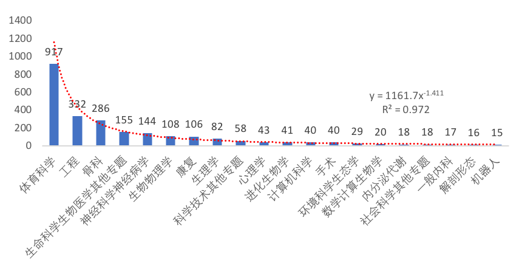

图4 跑的生物力学涉及前20研究领域

统计发现跑的生物力学共有含有54种学科领域，学科领域分布相对不平衡，整体呈现负指数分布（$y = 1161.7x^{-1.411}$，$R^2=0.972$）的其中Top5的领域为体育科学（SPORT SCIENCES），工程（ENGINEERING），骨科（ORTHOPEDICS），生命科学生物医学其他专题（LIFE SCIENCES BIOMEDICINE OTHER TOPICS）以及神经科学神经病学（NEUROSCIENCES NEUROLOGY）。

### 5.3.2 跑的生物力学研究学科领域叠加分析

科学领域的叠加分析是在当前大数据技术下，借助数据库中全体数据的关系建立的原始数据图层<sup>[19]</sup>。Loet Leydesdorff建立了一种跨学科分析方法（Interdisciplinaryscience），使用Web of Science的225种领域种类建立全科学领域分布图，将分类后的领域叠加在其上<sup>[20]</sup>。此方法可进行学科多样性的分析。通过Loet Leydesdorff的跨学科分析方法，将跑的生物力学包含的学科领域分为6类，再将分类后的领域通过VOSviewer叠加在全学科领域上。分类后的6类领域分布如图5。

[figure not shown]

图5 跑的生物力学全学科领域叠加

由此可以看出跑的生物力学主要从生物、医药、工程、计算机类别进行研究。而体育科学、骨科、生命科学生物医学其他专题和神经科学神经病学是跑的生物力学的主要研究领域。

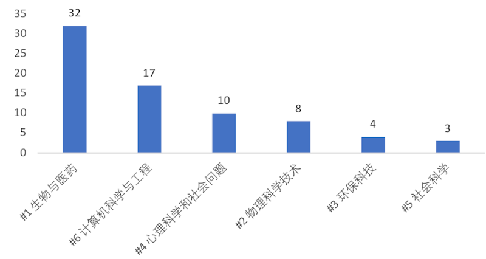

图6 跑的生物力学全学科领域分类

## 5.4 跑的生物力学研究热点与前沿

论文中标引出的关键词能够反映出文章的核心观点，是值得信赖的指标<sup>[21]</sup>。CiteSpace分析文献数据的关键词可以挖掘某研究主题的前沿和热点。将文献数据导入CiteSpace中，设置Time Slicing（时间跨度）为1985-2017年，Years Per Slice（时间切片）设置为1，Node type（节点类型）选择Keyword（关键词），LinkStrenth （连线强度）选择Consine算法，Selection Criteria （选择标准）为Top 30%，Pruning （网络裁剪）选择Minimum Spanning Tree（最小生成树）。Visualization（可视化）选择为Timezone View（时区视图），生成关键词图谱。 图中节点的大小代表关键词出现测次数，节点环代表年轮，字体的大小代表中介中心性，节点外有紫圈表示具有高中介中心性（大于0.1），节点内的红圈代表关键词具有高突现值。CiteSpace中的参数中介中心性（Centranlity）是测度节点在网络中重要性的指标，数值越大则在网络中的重要性越高。

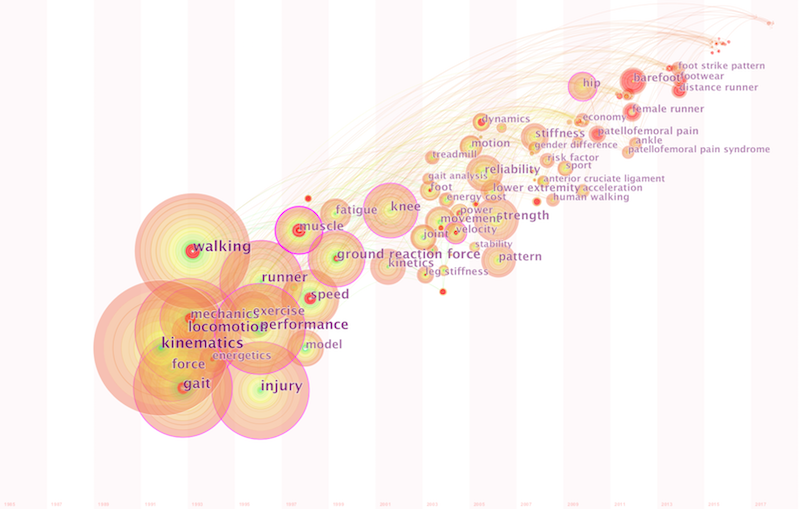

图7 关键词图谱

### 5.4.1 跑的生物力学研究热点

表3 高频词和高中介中心性关键词统计

| 出现频次 | 关键词 | 中文 | 中介中心性 | 关键词__1 | 中文__1 |
| --- | --- | --- | --- | --- | --- |
| 296 | kinematics | 运动学 | 0.24 | muscle | 肌肉 |
| 259 | walking | 行走 | 0.15 | performance | 性能 |
| 238 | locomotion | 运动 | 0.15 | runner | 跑者 |
| 217 | gait | 步态 | 0.15 | ground reaction force | 地面反作用力 |
| 211 | injury | 损伤 | 0.15 | knee | 膝 |
| 197 | performance | 表现 | 0.13 | gait | 步态 |
| 182 | runner | 跑者 | 0.13 | mechanics | 力学 |
| 148 | force | 力 | 0.13 | hip | 髋关节 |
| 141 | mechanics | 力学 | 0.11 | locomotion | 运动 |
| 136 | speed | 速度 | 0.11 | injury | 损伤 |

### 5.4.2 跑的生物力学研究前沿

表4 高突现值和高Sigma指数关键词统计

| 突现值 | 关键词 | 中文 | Sigma指数 | 关键词__1 | 中文__1 |
| --- | --- | --- | --- | --- | --- |
| 8.33 | barefoot | 裸足 | 1.65 | barefoot | 裸足 |
| 6.20 | parameter | 参数 | 1.43 | female runner | 女性跑者 |
| 5.96 | female runner | 女性跑者 | 1.16 | distance runner | 长跑运动员 |
| 5.64 | foot strike | 足着地 | 1.08 | variability | 易变性 |
| 5.39 | center of mass | 质量中心 | 1.07 | footwear | 鞋履 |
| 5.16 | footwear | 鞋履 | 1.05 | foot strike | 足着地 |
| 5.01 | distance runner | 长跑运动员 | 1.05 | iliotibial band syndrome | 髂胫束综合症 |
| 4.42 | children | 儿童 | 1.02 | parameter | 参数 |
| 4.05 | iliotibial band syndrome | 髂胫束综合症 | 1.01 | endurance | 耐力 |
| 3.98 | running injury | 跑步损伤 | 1.01 | minimalist | 极简主义 |

## 5.5 共被引分析

共引可以被定义为由其他文献共同引用两篇文献的频次，并被认为是文献的邻近度量<sup>[22]</sup>。本研究对文献数据包含的作者和引用文献进行共被引分析。CiteSpace中，设置Time Slicing（时间跨度）为1985-2017年，Years Per Slice（时间切片）设置为1，Node type（节点类型）选择cite reference（引用文献），LinkStrenth （连线强度）选择Consine算法，经过多次测试，Selection Criteria （选择标准）选择Threshold （阈值）（2，1，15）、（3，2，15）、（5，5，15），Pruning （网络裁剪）选择Minimum Spanning Tree（最小生成树）。

### 5.5.1 作者共被引分析

[figure not shown]

图8 作者共现图

表5 作者高被引次数和高中介中心性统计

| 作者 | 被引次数 | 中介中心性 |
| --- | --- | --- |
| Winter DA | 239 | 0.17 |
| Cavanagh PR | 193 | 0.16 |
| Nigg BM | 183 | 0.16 |
| Hreljac A | 105 | 0.11 |
| Williams KR | 68 | 0.13 |
| Bobbert MF | 61 | 0.15 |

此外，一些作者有高突现值，代表在短时间内作者的被引频率迅速提高。按照突变值排序，包括Farley CT（突变值=22.8，1997-2010）、Alexander RM（突变值=22.21，1993-2007）、Cavagna GA（突变值=21.79，1993-2007）、Biewener AA（突变值=16.06，2001-2011）、Mcmahon TA（突变值=15.83，1997-2007）、Blickhan R（突变值=13.77，1993-2011）、Seyfarth A（突变值=13.64，2003-2011）、Full RJ（突变值=11.66，1993-2011）、Mero A（突变值=11.23，2010-2013）、Mcclay I（突变值=10.63，2005-2011）。这些作者引导跑的生物力学的研究方向，具有代表性的意义。其中Cavanagh PR的文章具有较高的次被引、较高的中介中心性和较高的突变值（突变值=10.49，1985-2004）。Cavanagh PR为美国宾夕法尼亚州立大学运动研究中心教授，重点研究步态和人体运动，有理由认为他的研究在跑的生物力学中奠定了一定的知识基础，具有较高的权威性。

### 5.5.2 引用文献的共被引分析

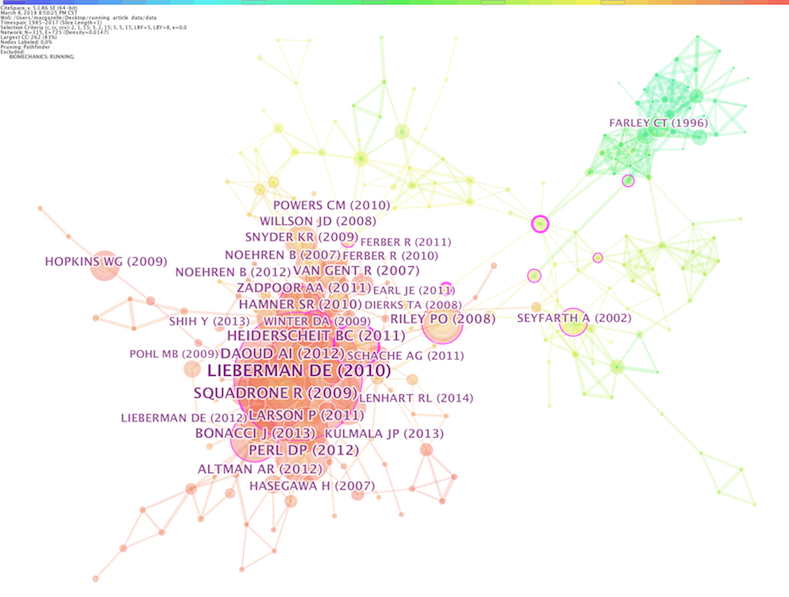

图9 跑的生物力学引用文献共被引网络

引用文献的共被引分析可以分析知识领域的基本知识结构，并展示引用文献的数量和权威性。在这一过程中，还可以确定共引集群，将被引文献进行聚类。根据Web of Science的被引次数，排名前20的引用文献总结在表6。图9和图10分别给出了包含315个节点和725个连接的引用文献共被引网络和引用文献共被引聚类。每个节点代表一篇文献，并标有第一作者的姓名和出版年份。每个连接表示两个对应文献之间的引用关系。节点大小表示节点文献的共引频率。应当指出的是，在文献数据中检索到的1619个文献中引用了32317篇文献，但不一定显示在图中。 根据被引次数，Lieberman DE<sup>[24]</sup>、Squadrone R<sup>[25]</sup>，Perl DP<sup>[26]</sup>位居前三位，被引次数分别是，96次、54次和43次。Lieberman DE<sup>[24]</sup>研究了裸足与穿鞋跑者脚与地面碰撞所造成的影响。研究表明习惯裸足跑运动员往往使用前足着地，并且在前脚着地之前让足跟下降，相反穿鞋跑者大多习惯于足后跟着地。前足和中足着地的步态可能更常见于裸足跑或穿着较小鞋码的人，这种着地方式可以保护一些运动员的足和下肢因地面接触而受伤。这篇论文在2010年在《Nature》中发表。Squadrone R<sup>[25]</sup>在跑台对裸足跑，穿五指鞋跑和穿标准运动鞋跑做了比较。发现有经验的裸足跑者在地面材质发生变化时会改变自身的跑步模式，另外穿着五指鞋跑在模仿裸足跑的跑步状态同时能提供少量的有效保护。Perl DP<sup>[26]</sup>测试了习惯穿着极简鞋或裸足的跑者，使他们穿着极简鞋和标准运动鞋在以3m/s的速度以相同的着地方式在跑台跑。研究发现无论何种着地方式，穿着极简鞋的跑者相对于穿着传统运动鞋的跑者都以显著性的表现出适当的经济性。并且认为这种差异的原因可能是穿着极简鞋跑步过程中下肢具有更大的弹性势能的储存与释放。  
被引次数排名前三的文章都与裸足跑相关，可以看出裸足跑在跑的生物力学研究中有重要的地位。

表6 文章高被引次数统计

| 序号 | 被引次数 | 中介中心性 | 文章 | 聚类号 | 序号__1 | 被引次数__1 | 中介中心性__1 | 文章__1 | 聚类号__1 |
| --- | --- | --- | --- | --- | --- | --- | --- | --- | --- |
| 1 | 96 | 0.12 | Lieberman DE<sup>[24]</sup> | 2 | 11 | 30 | 0.17 | Riley PO<sup>[27]</sup> | 2 |
| 2 | 54 | 0.12 | Squadrone R<sup>[25]</sup> | 2 | 12 | 28 | 0.02 | Altman AR<sup>[28]</sup> | 2 |
| 3 | 43 | 0.04 | Perl DP<sup>[26]</sup> | 5 | 13 | 27 | 0.05 | Kulmala JP<sup>[29]</sup> | 2 |
| 4 | 42 | 0.14 | Heiderscheit BC<sup>[30]</sup> | 2 | 14 | 26 | 0.06 | Noehren B<sup>[31]</sup> | 1 |
| 5 | 42 | 0.10 | Daoud AI<sup>[32]</sup> | 2 | 15 | 25 | 0.08 | Snyder KR<sup>[33]</sup> | 1 |
| 6 | 35 | 0.14 | Bonacci J<sup>[34]</sup> | 5 | 16 | 24 | 0.03 | Willson JD<sup>[35]</sup> | 1 |
| 7 | 34 | 0.04 | Larson P<sup>[36]</sup> | 2 | 17 | 23 | 0.03 | Hasegawa H<sup>[37]</sup> | 2 |
| 8 | 33 | 0.11 | Zadpoor AA<sup>[38]</sup> | 2 | 18 | 23 | 0.02 | Hopkins WG<sup>[39]</sup> | 12 |
| 9 | 33 | 0.10 | Hamner SR<sup>[40]</sup> | 4 | 19 | 23 | 0.01 | Powers CM<sup>[41]</sup> | 1 |
| 10 | 32 | 0.32 | van Gent R<sup>[42]</sup> | 2 | 20 | 23 | 0.00 | Noehren B<sup>[43]</sup> | 1 |

此外，一些文献具有高突变值，代表在短时间内论文的被引频率迅速提高。按照突变值排序，包括 Seyfarth A<sup>[44]</sup>（突变值=10.51，2003-2010）、 van Gent R<sup>[42]</sup>（突变值=9.87，2012-2015）、 Farley CT<sup>[45]</sup>（突变值=9.59，1997-2002）、 Riley PO<sup>[27]</sup>（突变值=9.46，2010-2013）、 Farley CT<sup>[46]</sup>（突变值=8.55，1997-2000）、 Hasegawa H<sup>[37]</sup>（突变值=8.24，2013-2015）、 Noehren B<sup>[31]</sup>（突变致=7.99，2012-2015）、 He JP<sup>[47]</sup>（突变值=7.54，1997-1999）、 Snyder KR<sup>[33]</sup>（突变值=7.46，2011-2013）、 Full RJ<sup>[48]</sup>（突变值=7.15，2001-2013）。  
这些文献给跑的生物力学带来新的研究导向，具有创新性的意义。其中van Gent R<sup>[42]</sup>与Riley PO<sup>[27]</sup>的文章具有较高的次被引数、较高的中介中心性和较高的突变值。有理由认为这两篇文章跑的生物力学中具有较高的重要性。

### 5.5.3 引用文献的共被引聚类分析

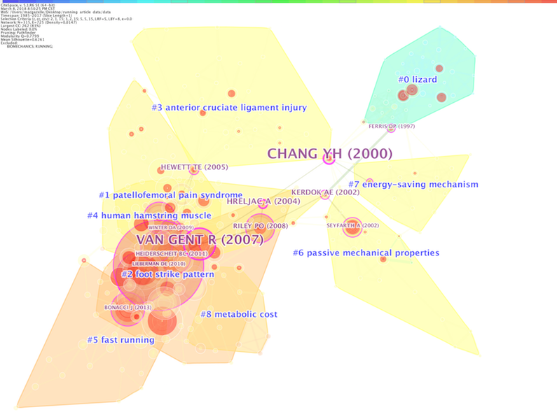

图10 跑的生物力学引用文献共被引聚类

聚类号#1，Silhouette值为0.731，平均发表年份为2008年，代表主题词为 patellofemoral pain syndrome（髌股关节疼痛综合征）。Snyder KR<sup>[33]</sup>在此类中具有最高的中介中心性（0.08）。Dierks TA<sup>[52]</sup>中介中心性排名第二（中介中心性为0.07）。Noehren B<sup>[31]</sup>在此类中具有最高的突现值（7.99）。此类主要是通过生物力学的方法研究跑的髋膝关节的损伤机制。 Snyder对15名女性通过6周的闭合式髋关节旋转练习，使用运动捕捉系统在跑步期间收集下肢的三维生物力学数据。研究发现练习使髋外展肌和外旋肌肌力得到加强，引起下肢关节负荷改变，从而可以降低损伤风险。 Dierks通过对20名患有髌股关节疼痛综合征（PFPS）跑者和20名健康跑者的横断面实验研究，发现在参与长期跑步前后髋关节外展力量和髋关节内收角度峰值。他认为髌股关节疼痛综合征患者具有较弱的髋关节外展肌，在跑步过程中会导致髋内收。 Noehren对一组健康的跑者进行了2年的追踪，其中18名跑者出现了髂胫束综合征（ITBS）。通过对患者髋膝的角度和力矩峰值进行比较，发现髋内收和膝内旋的力矩峰值增加可能导致髂胫束应变，从而压迫股骨外侧髁。

聚类号#2，Silhouette值为0.85，平均发表年份为2010年，代表主题词为footstrike pattern（着地模式） 聚类中van Gent R<sup>[42]</sup>有最高的中介中心性（0.32）和突现值（9.87）。Hreljac A<sup>[53]</sup>具有第二高的中介中心性（0.2）。Riley PO<sup>[27]</sup>的文章具有第二高的突现值（9.46）。此类为通过生物力学的方法对跑步的着地模式进行的研究。 van Gent R对长距离跑者下肢运动损伤的发生率和决定因素进行了综述，统计发现长距离跑者下肢损伤的发生率为19.4%~79.3%，其中膝关节为主要的损伤部位。另外发现男性跑者的每周的训练距离更长，具有受伤史的跑者更容易受伤。 Hreljac发现具有相对较低的冲击力的快速前旋步伐的跑步模式可以减少跑步过度带来的风险伤害。 Riley对20名受试者测量跑台与地面的运动学和动力学参数，结果发现跑台的运动学、动力学特征与地面相似，但膝关节的运动学、地面反作用力（GRF）峰值、关节力矩有显著性差别。 另外，结果显示此类中如Squadrone R<sup>[25]</sup>、Lieberman DE<sup>[24]</sup>、Daoud AI<sup>[32]</sup>、Heiderscheit BC<sup>[30]</sup>、Altman AR<sup>[28]</sup>等都具有较高的被引次数，并且他们研究的主题都是跑在不同状态下或穿着不同鞋的footstrike pattern（着地模式）。

聚类号#3，Silhouette值为0.943，平均发表年份为2002年，代表主题词为anterior cruciate ligament injury（前交叉韧带损伤）。此聚类中具有最高的中介中心性的论文为Chang YH<sup>[54]</sup>（中介中心性为0.35），Hewett TE<sup>[55]</sup>的中介中心（0.19）性排名第二。 Boden BP<sup>[56]</sup>具有最高的突现值（6.89）。此类主要通过测量跑、跳以及侧向运动时下肢肌肉韧带损伤的机制。 Chang YH通过在跑台上改变跑者的重力和惯性力测量运动学和动力学的数据，发现产生最大的垂直力随重力而变化，但不随质量而变化。在跑步过程中，重力相比于惯性能对地面的垂直力和水平分力产生更大的影响。 Hewett对参与足球、篮球、排球的205名女性运动员测量跳跃时下肢的关节角度和关节力矩，发现患有前交叉韧带断裂的运动员跳跃时的膝关节姿势与负荷与其他运动员有显著性不同。在跳跃落地时膝关节外翻和外展的负荷增加会增加女性运动员前交叉十字韧带的损伤风险。 Boden BP运用调查和录像回顾的方法，对82名前交叉韧带损伤的运动员进行了问卷调查和对27次运动员前交叉韧带损伤的录像进行了回顾。研究发现非接触性前交叉韧带损伤大多发生在运动方向发生改变或落地之前的突然减速，并认为股四头肌对前交叉韧带的断裂起到主要的作用。

聚类号#4，Silhouette值为0.692，平均发表年份为2008年，代表主题词为human hamstring muscle（人体大腿后群肌）。Winter DA<sup>[57]</sup>发表的一本专著为此类中的最高中介中心性（0.12）和突现值（5.58），Hamner SR<sup>[40]</sup> 中介中心性（0.1）排名第二。突现值排名第二的是Mero A<sup>[58]</sup>，突现值为4.74。此类主要研究跑的神经肌肉力学性质。 Winter对人体运动的生物力学与神经控制作出了阐述，这本专著运用现代科学和技术与解剖学、肌肉生理学和肌电图结合起来评估和理解人体运动。 Hamner开发了一种三维肌肉人体驱动的模拟系统，对跑的步态周期下肢肌肉进行了模拟。研究发现，跑的支撑早期阶段股四头肌是对支撑和制动具有最大的贡献，跑的支撑后期比目鱼肌和腓肠肌具有推进和支持的最大贡献。另外分析表明，股四头肌和跖屈肌肌力是运动过程中加速人体重心的主要因素。 Mero利用测力台与高速摄像机对9名男子短跑运动员的冲刺开始阶段进行测量，使用运动学与动力学分析关节力矩和力量。结果表明，力量产生开始时，在阻滞阶段腓肠肌和比目鱼肌的初始肌腱长度有助于踝关节力矩峰值和力量的增加，从而在冲刺开始阶段产生更大的阻滞速度。

聚类号#5，Silhouette值为0.836，平均发表年份为2012年，代表主题词为fast running （快速跑）。此类中Bonacci J<sup>[34]</sup>具有最高的中介中心性（0.14），Ridge ST<sup>[59]</sup>有排名第二的中介中心性（0.05）。Perl DP<sup>[26]</sup>具有最高的突变值（4.53），已在上文中作阐述。此类主要以生物力学方法研究跑的平衡与稳定性。 Bonacci通过测量地面反作用力和运动学数据，对22名跑者在裸足和穿着极简鞋、板鞋、普通运动鞋的情况下的差异进行了比较。结果显示，裸足跑在膝和踝关节的运动学及动力学参数上与穿鞋跑的参数之间存在显著差异。裸足跑在膝踝关节上的做功发生改变。 Ridge ST对36名有经验的休闲跑者分成两组，对照组穿着传统的跑鞋，实验组从穿着传统跑鞋逐渐过渡到极简跑鞋。通过10周的测试，对下肢进行核磁共振成像。结果发现穿实验组在10周后有$\frac{10}{19}$的跑者骨骼中的骨髓水肿显著性增加。

聚类号#6，Silhouette值为0.933，平均发表年份为2002年，代表主题词为passive mechanical properties（被动机械性能）。Seyfarth A<sup>[44]</sup>的中介中心性最高（0.13）同时也具有最高的突现值（10.51），排名第二的为Full RJ<sup>[60]</sup>（中介中心性为0.06）。此类主要是通过生物力学的方法来研究跑的平衡稳定机制。 Seyfarth讨论了跑步动作的标准，他认为跑在对于确定的下肢攻角而言，如果速度增加，腿部的刚度需要适当调整则人体系统会变得稳定。而在给定速度的情况下，腿部几乎都是使用最大的力量来实现稳定的跑步模式。 Full让6位受试者从柔软的表面跑到坚硬的表面，发现在跑步的支撑时期，人体重心的的垂直位置并不受地面硬度的影响，跑者可以通过快速调整腿部的刚度来实现在不同表面的过渡。

## 5.7 结论

通过可视化的分析，我们对跑的生物力学文献进行了系统的回顾。一方面我们对文献的时空维度和学科领域进行了分析，另一方面我们对文献的主要内容进行了阐述。跑的生物力学2004年后文献量增长加快。其研究的国家主要为美国、英国等发达国家，研究机构主要分布在美洲和欧洲。跑的生物力学涉及多学科领域，主要集中在生物与医药领域，在Web of Science分类中体育科学是主要的成分。跑的生物力学主要是测量运动学，地面的反作用力对不同的人群及鞋履的基本步态、运动表现、肌肉力学性质和损伤机制进行研究。其研究内容主要为：基本步态、髌股关节疼痛综合征、着地模式、前交叉韧带损伤、肌肉力学性质、鞋履以及跑的稳定性。不同鞋履的运动表现与跑的着地方式已成为研究热点和未来的研究趋势。

# 参考文献

[1] 凤凰网体育. 2017中国马拉松大数据分析报告[J]. http://sports.ifeng.com/a/20180125/55462768_0.shtml.

[2] SHIH Y 等. Is the foot striking pattern more important than barefoot or shod conditions in running?[J]. 2013, 38(3): 490–4.

[3] SYNNESTVEDT M B 等. CiteSpace II: visualization and knowledge discovery in bibliographic databases.[J]. AMIA ... Annual Symposium proceedings / AMIA Symposium. AMIA Symposium, 2005, 2005: 724.

[4] 李杰陈超美. citespace:科技文本挖掘及可视化[M]. 首都经济贸易大学出版社, 2016.

[5] 陈瑶瑶, 倪依克. 2008年以来我国民族传统体育研究进展–基于Citespace Ⅲ的计量分析[J]. 中国体育科技, 2016, 52(2): 12–18.

[6] 陈小虎 等. 国外足球耐力热点研究及其变化趋势分析[J]. 中国体育科技, 2016, 52(3): 110–118.

[7] 高明 等. 基于CiteSpaceIII的国外体育教育研究计量学分析[J]. 体育科学, 2015(1): 4–12.

[8] 江婉婷 等. 国外肌肉衰减综合征的运动疗法研究热点与内容分析——基于科学知识图谱的可视化研究[J]. 体育科学, 2017, 37(6): 75–83.

[9] 刘兰娟 等. 国际瑜伽研究演进脉络与前沿动态的体育竞争情报分析[J]. 中国体育科技, 2015(2): 105–113.

[10] 石岩, 霍炫伊. 体育运动风险研究的知识图谱分析[J]. 体育科学, 2017, 37(2): 76–86.

[11] 水祎舟 等. 国外足球运动体能训练前沿热点与演化分析——基于科学知识图谱的可视化研究[J]. 体育科学, 2016(1): 67–78.

[12] 王俊杰 等. 基于知识图谱的国外太极拳运动研究热点与演化分析[J]. 体育科学, 2012, 32(10): 77–84.

[13] 夏培玲, 王璟. 基于知识图谱的国外高原训练研究前沿与热点分析[J]. 体育科学, 2011, 31(4): 75–80.

[14] 张毅恒, 柳鸣毅. 基于知识图谱的中国体育产业研究可视化分析[J]. 中国体育科技, 2016, 52(1): 24–29.

[15] 赵丙军. 国外力量训练研究知识来源载体网络的结构演化特征[J]. 中国体育科技, 2015(1): 3–19.

[16] BARTLETT R M. The biomechanics of the discus throw: a review.[J]. Journal of sports sciences, 1992, 10(5): 467–510.

[17] 陈超美 等. CiteSpace Ⅱ:科学文献中新趋势与新动态的识别与可视化[J]. 情报学报, 2009, 28(3): 401–421.

[18] PORTER A L, YOUTIE J. Where does nanotechnology belong in the map of science?[J]. Nature Nanotechnology, 2009, 4(9): 534.

[19] 李杰. 安全科学结构及主题演进特征研究–基于Web of Science科技文本知识单元共现分析的探索[D]. 首都经济贸易大学, 2016.

[20] LEYDESDORFF L 等. Global maps of science based on the new Web-of-Science categories[J]. Scientometrics, 2013, 94(2): 589–593.

[21] 韩增林 等. 基于CiteSpace中国海洋经济研究的知识图谱分析[J]. 地理科学, 2016, 36(5): 643–652.

[22] HOWARD R, BJÖRK B C. Building information modelling – Experts’ views on standardisation and industry deployment[J]. Advanced Engineering Informatics, 2008, 22(2): 271–280.

[23] CHEN C, PAUL R J. Visualizing a Knowledge Domain’s Intellectual Structure[J]. Computer, 2001, 34(3): 65–71.

[24] LIEBERMAN D E 等. Foot strike patterns and collision forces in habitually barefoot versus shod runners.[J]. Nature, 2010, 463(7280): 531–5.

[25] SQUADRONE R, GALLOZZI C. Biomechanical and physiological comparison of barefoot and two shod conditions in experienced barefoot runners.[J]. J Sports Med Phys Fitness, 2009, 49(1): 6.

[26] PERL D P 等. Effects of footwear and strike type on running economy.[J]. Med Sci Sports Exerc, 2012, 44(7): 1335–43.

[27] RILEY P 等. A kinematics and kinetics comparison of overground and treadmill running[J]. 2008.

[28] ALTMAN A R, DAVIS I S. A kinematic method for footstrike pattern detection in barefoot and shod runners.[J]. 2012, 35(2): 298–300.

[29] KULMALA J P 等. Forefoot strikers exhibit lower running-induced knee loading than rearfoot strikers.[J]. Med Sci Sports Exerc, 2013, 45(12): 2306–2313.

[30] HEIDERSCHEIT B C 等. Effects of step rate manipulation on joint mechanics during running.[J]. 2011, 43(2): 296.

[31] NOEHREN B. ASB Clinical Biomechanics Award Winner 2006: Prospective study of the biomechanical factors associated with iliotibial band syndrome[J]. Clinical Biomechanics, 2007, 22(9): 951.

[32] DAOUD A I 等. Foot strike and injury rates in endurance runners: a retrospective study[J]. 2012, 44(7): 1325–34.

[33] SNYDER K R 等. Resistance training is accompanied by increases in hip strength and changes in lower extremity biomechanics during running[J]. Clinical Biomechanics, 2009, 24(1): 26–34.

[34] BONACCI J 等. Running in a minimalist and lightweight shoe is not the same as running barefoot: a biomechanical study[J]. British Journal of Sports Medicine, 2013, 47(6): 387–92.

[35] WILLSON J D, DAVIS I S. Lower extremity mechanics of females with and without patellofemoral pain across activities with progressively greater task demands[J]. Clinical Biomechanics, 2008, 23(2): 203.

[36] LARSON P 等. Foot strike patterns of recreational and sub-elite runners in a long-distance road race[J]. Journal of Sports Sciences, 2011, 29(15): 1665.

[37] HASEGAWA H, INUI F. Influence of higher-grade walking on metabolic demands in young untrained Japanese women[J]. 2007, 21(2): 405.

[38] ZADPOOR A A, NIKOOYAN A A. The relationship between lower-extremity stress fractures and the ground reaction force: a systematic review[J]. Clinical Biomechanics, 2011, 26(1): 23–28.

[39] HOPKINS W G 等. Progressive statistics for studies in sports medicine and exercise science.[J]. 2009, 41(1): 3.

[40] HAMNER S R 等. Muscle contributions to propulsion and support during running[J]. Journal of Biomechanics, 2010, 43(14): 2709.

[41] POWERS C M. The Influence of Abnormal Hip Mechanics on Knee Injury: A Biomechanical Perspective[J]. 2010, 40(2): 42.

[42] GENT R N van 等. Incidence and determinants of lower extremity running injuries in long distance runners: a systematic review.[J]. Br J Sports Med, 2007, 41(8): 469.

[43] NOEHREN B 等. Proximal and distal kinematics in female runners with patellofemoral pain[J]. Clinical Biomechanics, 2012, 27(4): 366–371.

[44] SEYFARTH A 等. A movement criterion for running.[J]. Journal of Biomechanics, 2002, 35(5): 649.

[45] FARLEY C T, GONZÃ lez O. Leg stiffness and stride frequency in human running[J]. Journal of Biomechanics, 1996, 29(2): 181–6.

[46] FARLEY C T 等. Running springs: speed and animal size.[J]. Journal of Experimental Biology, 1993, 185(185): 71.

[47] HE J P 等. Mechanics of running under simulated low gravity[J]. Journal of Applied Physiology, 1991, 71(3): 863–70.

[48] FULL R J, KODITSCHEK D E. Templates and anchors: neuromechanical hypotheses of legged locomotion on land[J]. Journal of Experimental Biology, 1999, 202(Pt 23): 3325–3332.

[49] TRAUWAERT E 等. Some silhouette-based graphics for clustering interpretation[J]. 1989, 29(3).

[50] FERRIS D P, FARLEY C T. Interaction of leg stiffness and surfaces stiffness during human hopping.[J]. Journal of Applied Physiology, 1997, 82(1): 15–22.

[51] ROBERTS T J 等. Muscular force in running turkeys: the economy of minimizing work.[J]. Science, 1997, 275(5303): 1113–5.

[52] DIERKS T A 等. Proximal and Distal Influences on Hip and Knee Kinematics in Runners With Patellofemoral Pain During a Prolonged Run[J]. J Orthop Sports Phys Ther, 2008, 38(8): 448–456.

[53] HRELJAC A. Impact and overuse injuries in runners[J]. 2004, 36(5): 845.

[54] CHANG Y H 等. The independent effects of gravity and inertia on running mechanics[J]. Journal of Experimental Biology, 2000, 203(2): 229–38.

[55] HEWETT T E 等. Biomechanical measures of neuromuscular control and valgus loading of the knee predict anterior cruciate ligament injury risk in female athletes: a prospective study.[J]. American Journal of Sports Medicine, 2005, 33(4): 492.

[56] BODEN BP 等. Mechanisms of anterior cruciate ligament injury[J]. Orthopedics, 2000, 3(23): 573–578.

[57] WINTER D A. Biomechanics and motor control of human movement[M]. John Wiley & Sons, 2009.

[58] MERO A 等. Effects of muscle – tendon length on joint moment and power during sprint starts[J]. J Sports Sci, 2006, 24(2): 165–173.

[59] RIDGE S T 等. Foot bone marrow edema after a 10-wk transition to minimalist running shoes.[J]. 2013, 45(7): 1363.

[60] FERRIS D P 等. Runners adjust leg stiffness for their first step on a new running surface[J]. Journal of Biomechanics, 1999, 32(8): 787–794.

[61] MINETTI A E 等. The relationship between mechanical work and energy expenditure of locomotion in horses.[J]. Journal of Experimental Biology, 1999, 202(17): 2329–2338.

[^1]: 在Web of Science 中星号 （*）为通配符， 表示任何字符组，包括空字符。run*可以搜索run、running、runer等英文单词。
[^2]: 可视化交互图可以访问：http://www.gaomm.top/data/tu.html 浏览。